# Machine Learning Prediction of Exercise Performance

Practical Machine Learning Course Project

Patrick Simon

30 7 2019

## Summary

Participants of a study were asked to perform strength exercises either correctly, or in one of four wrong ways, while wearing electronic monitoring devices. This project aims to use machine learning methods to develop a model that can reliably predict these five categories based on the various available measurement variables. A very reliable prediction model with an accuracy of over 99% is obtained using a random forest algorithm with 5-fold cross validation.

## Reading the data

The data, which has graciously been provided by Ugulino et al. at : http://groupware.les.inf.puc-rio.br/har, must first be loaded into R. There is a training set and a test set. Many of the entries are either not available, empty string, or division by zero errors. All of these will be read as `NA`.

```r
## Check if the files are downloaded, otherwise do so
if(!("pml-training.csv" %in% dir())) {
fileUrl <- "https://d396qusza40orc.cloudfront.net/predmachlearn/pml-training.csv"
download.file(fileUrl,destfile="pml-training.csv",method="libcurl")
}
if(!("pml-testing.csv" %in% dir())) {
fileUrl <- "https://d396qusza40orc.cloudfront.net/predmachlearn/pml-testing.csv"
download.file(fileUrl,destfile="pml-testing.csv",method="libcurl")
}

alltrain <- read.csv("pml-training.csv",header=TRUE,
                  stringsAsFactors=T,na.strings=c("NA","","#DIV/0!"))
alltest <- read.csv("pml-testing.csv",header=TRUE,
                  stringsAsFactors=T,na.strings=c("NA","","#DIV/0!"))
```

The test set will be left aside until the very end, for validation. The training set will be split further into a new training and test set. A random seed is set for the sake of reproducibility.

```r
library(caret)
RNGversion("3.6.0")
set.seed(481516)

inTrain <- createDataPartition(y=alltrain$classe, p=0.7, list=FALSE)
training <- alltrain[inTrain,]
testing <- alltrain[-inTrain,]
```

## Exploratory analysis

First off, all columns in which more than 90% of the entries consists of `NA` values will be removed. Furthermore, the first seven columns, which contain only subject identifiers and timestamps, will also be removed.

```r
goodcols <- colSums(is.na(training))/dim(training)[1] < 0.9
gtrain <- training[,goodcols]
gtrain <- gtrain[,-(1:7)]

ci <- which(colnames(gtrain)=="classe")
dim(gtrain) ; ci
```

```
## [1] 13737    53
```

```
## [1] 53
```

There are 53 remaining columns, the last of which contains the outcome variable `classe`.

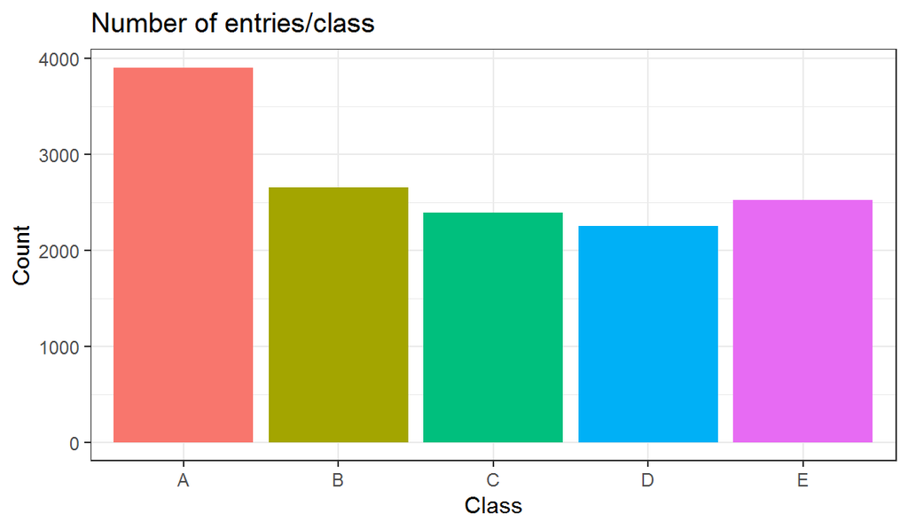

Figure 1: Number of entries per category in the training subset (which makes up 70% of the entire training set).

```r
library(ggplot2)
qplot(gtrain$classe,fill=gtrain$classe) + theme_bw() +
        labs(x="Class",y="Count",title="Number of entries/class") +
        theme(legend.position = "")
```

## Chosing and training the model

One of the machine learning algorithms that show the best results for classifications are random forests. In order to increase accuracy further, a number of different cross-validation methods are available. In order not to inflate the long time it takes to calculate the model, a k-fold cross validation with `k = 5` was chosen.

```r
set.seed(2342)
trc <- trainControl(method="cv", number=5)
modelFit <- train(y=gtrain[,ci],x=gtrain[,-ci],method="rf",trControl=trc)
modelFit$finalModel
```

```
##
## Call:
##  randomForest(x = x, y = y, mtry = param$mtry)
##                Type of random forest: classification
##                      Number of trees: 500
## No. of variables tried at each split: 27
##
##         OOB estimate of  error rate: 0.62%
## Confusion matrix:
##      A    B    C    D    E  class.error
## A 3903    1    1    0    1 0.0007680492
## B   18 2637    3    0    0 0.0079006772
## C    0   14 2376    6    0 0.0083472454
## D    0    0   23 2228    1 0.0106571936
## E    0    3    6    8 2508 0.0067326733
```

The model estimates an out-of-bag error rate of less than 1%. To further confirm the quality of the model, we can use it to predict the outcome for the data in our test subset from the initial training data.

```r
gtest <- testing[,goodcols]
gtest <- gtest[,-(1:7)]

tpred <- predict(modelFit,gtest[,-ci])
conf <- confusionMatrix(tpred,gtest$classe)

conf$table
```

```
##           Reference
## Prediction    A    B    C    D    E
##          A 1672    6    0    0    0
##          B    2 1124    6    2    0
##          C    0    9 1015   12    0
##          D    0    0    5  948    3
##          E    0    0    0    2 1079
```

```r
conf$overall[1]
```

```
##  Accuracy
## 0.9920136
```

Again, we have very good agreement between the predictions and the actual classes, with 99.201% accuracy, which leads us to an estimated out-of-bag error of 0.799%. A visualization of the confusion matrix can be seen in Figure 2.

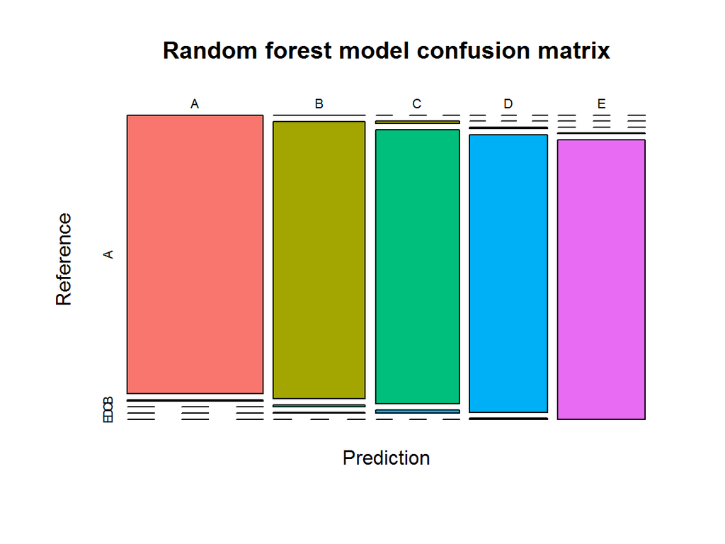

Figure 2: Confusion matrix for the comparison between the actual and predicted categroy values for the test subset

```r
chue <- function(n) {
        hues = seq(15, 375, length = n + 1)
        hcl(h = hues, l = 65, c = 100)[1:n]
}
cols=chue(5)
plot(conf$table,col=cols, main="Random forest model confusion matrix")
```

With such an accurate result, it is unnecessary to consider alternate algorithms.

## Predictions for the validation set

In the final step, the model will be applied to predict the categories for the 20 entries in the validation set.

```r
gvalid <- alltest[,goodcols]
gvalid <- gvalid[,-(1:7)]

vpred <- predict(modelFit,gvalid[,-ci])
vpred
```

```
##  [1] B A B A A E D B A A B C B A E E A B B B
## Levels: A B C D E
```